# hw1

## Homework 1

### Youyu Zhang

```python
import numpy as np
import matplotlib.pyplot as plt
import seaborn as sns
import random
```

1. Generate a normal distribution (mean = 7, standard deviation = 2) , for three different sample sizes 100,1000,100,000. Design a python class to get the following items:

a) Show the density curve for all the three sample sizes (5 points)

b) Explain the findings for all three samples (5 points)

c) Convert the simulated data into a standard normal distribution, and plot for all three different sample sizes. (5 points)

## Answer

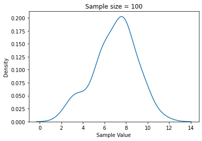

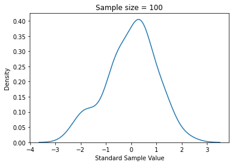

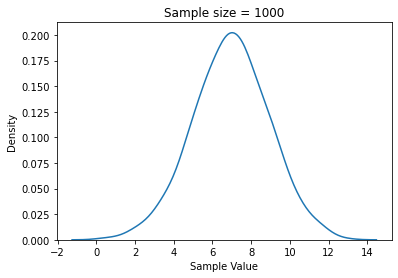

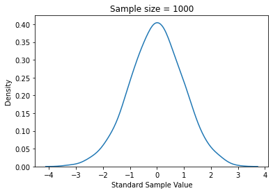

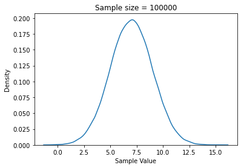

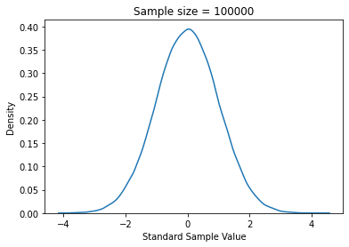

```python
class Question1:
    samplesize = [100, 1000, 100000]
    mean_value = 7
    std_value = 2

    for i in samplesize:
        s = np.random.normal(mean_value, std_value, i)
        #(a)
        sns.distplot(s, hist=False)
        plt.ylabel('Density')
        plt.xlabel('Sample Value')
        plt.title(f'Sample size = {i}')
        plt.show()
        #(c) Convert into standard normal distribution and plot
        s_standard = (s-mean_value)/std_value
        sns.distplot(s_standard, hist=False)
        plt.ylabel('Density')
        plt.xlabel('Standard Sample Value')
        plt.title(f'Sample size = {i}')
        plt.show()
```

1. Generate a standard normal distribution for three different sample sizes 100, 5000, 50,000. Design a python class to get the following items:

a) Show the density curve for all the three sample sizes (5 points)

b) Explain the findings for all three samples (5 points)

## Answer

(b) Most datapoints fall around 0, less datapoints fall out both sides. Larger sample sizes will result smoothier density curves and more density around standard sample value = 0.

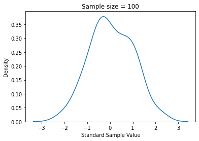

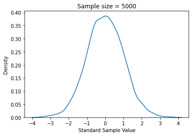

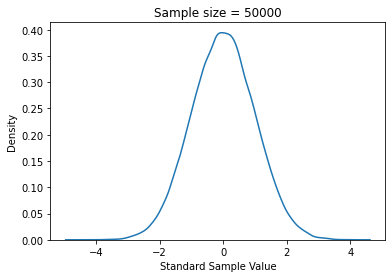

```python
class Question2:
    samplesize = [100, 5000, 50000]

    for i in samplesize:
        s = np.random.standard_normal(i)
        sns.distplot(s, hist=False)
        plt.ylabel('Density')
        plt.xlabel('Standard Sample Value')
        plt.title(f'Sample size = {i}')
        plt.show()
```

1. Binomial Distribution simulation. Generate a random number between 0 and 1. If that number is 0.5 or more, then event it as fake. Otherwise not a fake for 500, 5000, and 500,000 trails.

Design a python class to get the following items:

a) Show the density curve for all the three sample sizes (5 points)

b) Explain the findings for all three samples (5 points)

## Answer

(b) The highest density occured at about 0.5*trials. For example, 500 trials will give result in most success probability at around 250 success cases.

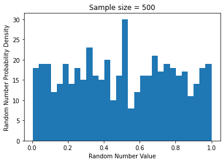

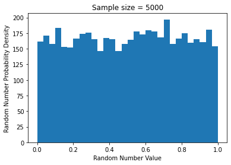

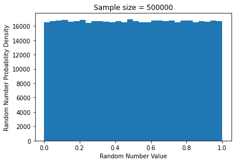

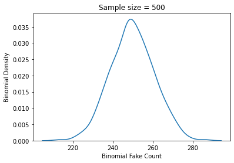

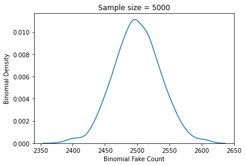

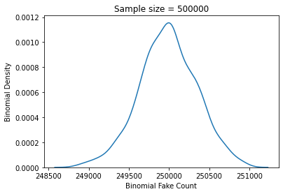

```python
class Question3:
    trials = [500, 5000, 500000]

    for i in trials:
        randlist = list(np.random.random_sample(size =i))
        count_fake = 0
        for j in randlist:
            if j >= 0.5:
                count_fake += 1
        plt.hist(randlist, 30)
        plt.ylabel('Random Number Probability Density')
        plt.xlabel('Random Number Value')
        plt.title(f'Sample size = {i}')
        plt.show()

    for i in trials:
        # n: number of trials
        # p: probability of getting fake for a single trial
        # size: repeated tests for the whole x trials.
        dist = np.random.binomial(n=i, p=0.5, size=1000)
        sns.distplot(dist, hist=False)
        plt.ylabel('Binomial Density')
        plt.xlabel('Binomial Fake Count')
        plt.title(f'Sample size = {i}')
        plt.show()
```